# Homework #0: The Case of the Mystery Coins: Solution

First we read in the data, converting the strings of H/T to a number of Heads and a number of Tails.

```r
datafile <- "coin_flips.txt"
flip_text <- strsplit(scan(datafile, what=''), "")
nflips <- sapply(flip_text, length)
nheads <- sapply(flip_text, function (x) sum(x=="H"))
ntails <- sapply(flip_text, function (x) sum(x=="T"))
stopifnot(all(ntails == nflips - nheads))
```

There are 100 coins in the dataset, that were flipped between 1 and 24 times, with a median of 8 flips. The number of flips per coin breaks down as follows:

```r
table(nflips)
```

```
## nflips
##  1  2  3  4  5  6  7  8  9 10 11 12 13 14 15 16 17 22 24
##  2  4  6  6  3 14 10 15 11  6  3  7  4  1  3  1  1  1  2
```

The proportion of heads varies substantially: here is a plot of the proportion of heads against the number of flips, slightly jittered to avoid overplotting.

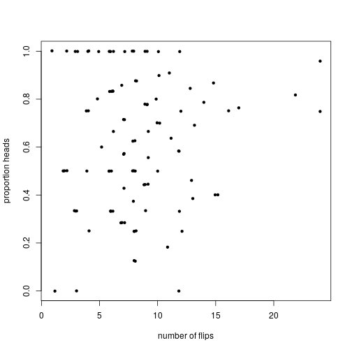

```r
plot(jitter(nflips), jitter(nheads/nflips), xlab='number of flips',
     ylab='proportion heads', pch=20)
```

The coins tend towards Heads, although they certainly don’t all have the same probability of coming up heads: observe that one coin flipped 12 times had no heads, while another, also flipped 12 times, had 12 heads.

From Wikipedia, the Beta-Binomial distribution ( for the number of heads among $n$ flips of a coin whose probability of heads (which we denote $\theta$) has a Beta($\alpha$, $\beta$) distribution) is
$$\begin{aligned}
p(k|n, \alpha, \beta) = \binom{n}{k} \frac{B(k + \alpha, n - k + \beta)}{B(\alpha, \beta)} ,
\end{aligned}$$
where $B()$ is the Beta function. That’s the probability that a *particular* coin that was flipped $n$ times gets $k$ heads; we are assuming that the sequence of flips coming from *each* coin is an independent result of this random process, with common $\alpha$ and $\beta$ parameters determining the distribution of $\theta$ across the coins (i.e., how the probability of heads varies between coins). Using the R functions `lchoose()` and `lbeta()` for the logarithm of the “choose” function $\binom{n}{k}$ and the Beta function, respectively, the log-likelihood of the data for a given set of `params =`$(\alpha, \beta)$ is

```r
loglik <- function (params) {
    sum( lchoose(nflips, nheads) +
         lbeta(nheads + params[1], ntails + params[2]) -
         lbeta(params[1], params[2]) )
}
```

There are only two parameters, so to get a picture of the result we’ll do a grid search.

```r
ngrid <- 51
maxgrid <- 10
alpha_vals <- beta_vals <- seq(0,maxgrid,length.out=ngrid)[-1]
ab <- expand.grid(alpha=alpha_vals, beta=beta_vals)
ll_mat <- apply(ab, 1, loglik)
dim(ll_mat) <- c(length(alpha_vals), length(beta_vals))

mle <- ab[which.max(ll_mat),]
```

The MLE obtained by this grid search is $\alpha = 2.6$ and $\beta = 1.6$, at which point the log-likelihood is -200.3388174.

The (log-)likelihood surface has a single peak, so after some adjusting of the parameters, we end up with the following picture:

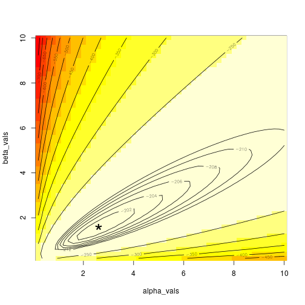

```r
image(alpha_vals, beta_vals, ll_mat)
contour(alpha_vals, beta_vals, ll_mat, add=TRUE)
contour(alpha_vals, beta_vals, ll_mat, add=TRUE,
        levels=pretty(ll_mat[which.max(ll_mat)] - 0:10))
points(mle[1], mle[2], pch="*", cex=3)
```

We could use gradient descent (as in the R function `optim()` to get an estimate of $\alpha$ and $\beta$ with more digits after the decimal, but it is clear from the likelihood surface that this would be false precision: there is an elliptical region over which $\alpha$ ranges from about 2 to 4 and $\beta$ ranges from about 1 to 2 on which the log-likelihood differs from the MLE by only two units; any reasonable confidence interval would roughly agree with this region.

In conclusion, our best guess at the distribution of true-probabilities-of-heads in my bag of coins is Beta(2.6, 1.6), which looks like:

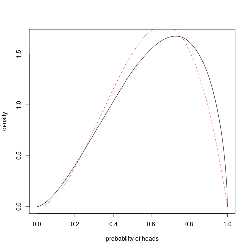

```r
xx <- seq(0, 1, length.out=400)
plot(xx, dbeta(xx, shape1=mle$alpha[1], shape2=mle$beta[1]), type='l',
     xlab='probability of heads', ylab='density')
lines(xx, dbeta(xx, shape1=3, shape2=2), col='red', lty=3)
```

The true values used to simulate these data werre $\alpha = 3$ and $\beta = 2$, shown in red on the graph – not bad.

## Outliers?

Are *all* the coins consistent with this distribution of probabilities? To get an idea of this we can compute the “$z$-scores” for each coin: the difference of the observed value from the mean, divided by the SD. Again from Wikipedia, the mean of a Beta-binomial of $n$ flips is $n \alpha / (\alpha + \beta)$ and the variance is $n \alpha \beta (\alpha + \beta + n) / ((\alpha + \beta)^2 (\alpha + \beta + 1))$. Surprising outcomes should have large values of $z$ (either positive or negative).

```r
alpha <- mle$alpha[1]
beta <- mle$beta[1]
means <- nflips * alpha / (alpha + beta)
sds <- sqrt(nflips * alpha * beta * (alpha + beta + nflips) / ((alpha + beta)^2 * (alpha + beta + 1)))
z <- (nheads - means) / sds
```

Here is a stem-and-leaf plot of the $z$-scores:

```r
biggest_z <- which.max(abs(z))
stem(z)
```

```
##
##   The decimal point is at the |
##
##   -2 | 5
##   -2 |
##   -1 | 99975
##   -1 | 44432222210000
##   -0 | 999999777765555
##   -0 | 4444333222111
##    0 | 001223334444
##    0 | 556666667788888999
##    1 | 00001222223444444
##    1 | 55555
```